# Machine Learning in Nuclear Physics (1)

Author: Jiangming Yao (FRIB/NSCL, MSU)

## Introduction

In the Generator-Coordinate Method (GCM), the model space for nuclear low-lying states is truncated based on the choice of collective coordinates ($q_i$), which can be either quadrupole deformation $\beta_2$, pairing amplitude $\Delta$ or cranking frequency $\omega$, etc. This truncation scheme provides an effective way to capture relevant correlations in the model space. For the matrix elements of neutrinoless double beta decay, both the collective orrelation (deformation $\beta$) and neutron-proton isoscalar pairing amplitude $\phi_{np}$ should be chosen. The key ingredients of the GCM are the kernels related to the observables of interest. The number of the kernels to be calculated scales as $O(N^{2d})$, where $N$ is the number of configurations for each type of collective coordinates and $d$ is the number of types of collective coordinates. Therefore, there is a trade off between the number of collective coordinates and the computation time. Different from what the Monte-Carlo shell model does based on the stochastic sampling of configurations, we introduce machine-learning techniques to reduce the computation time. The procedure can be as follows:

- Discretize the $d$-dimension collective space with a relatively large step along each direction and calculate the kernels on the mesh points exactly using nuclear models. The values of these kernels serve as the dataset for both model training and model validation.
- Use machine learning techniques to train a model for the kernels (including Hamiltonian and norm kernels) in the $d$-dimensional space using parameterized Gaussian functions.
- Use the trained model to predict/interpolate the kernels in the collective space with denser mesh points.
- Solve the Hill-Wheeler equation and calculate the observables of interest using all the kernels (including the exactly calculated ones and model predicted ones).

As a demonstration, in this notebook, we take the following nuclear model in the calculation:

- GCM+HFB(with constrains on the quadrupole deformation $\beta_2$)
- Effective interaction KB3G defined within $fp$ shell

We take $^{48}$Ti as an example.

We adopt both conventional Machine Learning (ML) approach and deep learning approach for comparison.

# The Methods

## Nuclear models

Introduction to the nuclear models can be found on [arXiv](https://arxiv.org/pdf/1807.11053.pdf) or [Physical Review C](https://journals.aps.org/prc/abstract/10.1103/PhysRevC.98.054311).

The results by the nuclear model calculation are stored in a file, "data4ML.dat".

## Interpolation Methods

We adopt three methods to do interpolation:

- conventional machine learning
- Spline interpolation
- Neural network.

```python
from sklearn.pipeline import  Pipeline
from sklearn.preprocessing import StandardScaler,PolynomialFeatures,RobustScaler,MinMaxScaler
from sklearn.svm import SVR
from sklearn.model_selection import train_test_split
from sklearn.linear_model import LinearRegression
from sklearn.metrics import mean_squared_error

import pandas as pd
import numpy as np
import matplotlib.pyplot as plt
import seaborn as sns

import scipy.interpolate as interp

from matplotlib.ticker import MultipleLocator, FormatStrFormatter
from matplotlib.ticker import AutoMinorLocator
import matplotlib.ticker as ticker
minorLocator = AutoMinorLocator()

blacksolid ={'color':'k',
        'linestyle': '-'}

blackdot ={'color':'k',
        'linestyle': ':'}

blackdashdot ={'color':'k',
        'linestyle': '-.'}

redsolid ={'color':'r',
        'linestyle': '-'}
bluedash ={'color':'b',
        'linestyle': '--'}

fs= 18


plt.rcParams['figure.figsize'] = (7, 7) # set default size of plots
```

```python
from SNN import *
from gcm import *
```

## Dataset

Introduction to the data:

- bet1, bet2 are for the quadrupole deformations of reference states.
- nn is for the norm kernel, $$ <\beta_1 | P^J P^N P^Z| \beta_2> $$
- hh is for the Hamiltonian kernel, normalized with the norm kernel, $$ \dfrac{<\beta_1 | H P^J P^N P^Z| \beta_2>}{<\beta_1 | P^J P^N P^Z| \beta_2>}. $$

### Load data

```python
data = pd.read_csv("data4ML.dat")
features = ['JJ','q1','q2','bet1','bet2','nn','hh']
data = data[features]

data0 = data
data.head()
```

|  | JJ | q1 | q2 | bet1 | bet2 | nn | hh |
| --- | --- | --- | --- | --- | --- | --- | --- |
| 0 | 0 | 1 | 1 | -0.35 | -0.35 | 0.056751 | -19.248030 |
| 1 | 0 | 2 | 1 | -0.30 | -0.35 | 0.055657 | -20.415483 |
| 2 | 0 | 3 | 1 | -0.25 | -0.35 | 0.049036 | -21.459291 |
| 3 | 0 | 4 | 1 | -0.20 | -0.35 | 0.040537 | -22.473485 |
| 4 | 0 | 5 | 1 | -0.15 | -0.35 | 0.032881 | -23.320063 |

### Visualization

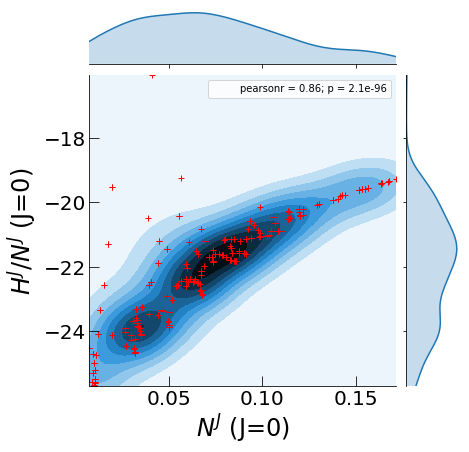

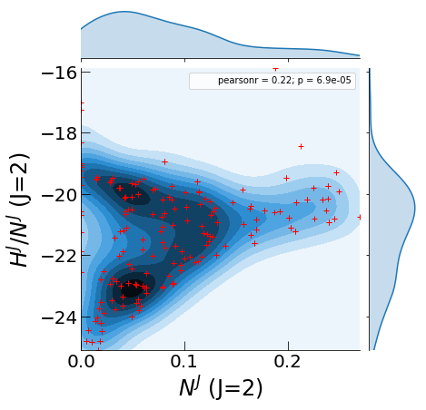

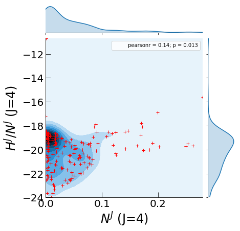

```python
plot_dist_nn_hh(data,6)
```

**plot the H/N and N for J=0**

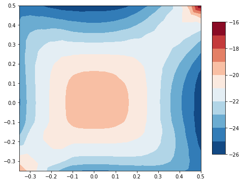

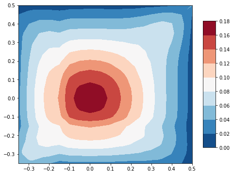

```python
data0 = data[data['JJ']==0]
q1 = data0['bet1']
q2 = data0['bet2']
hh = data0['hh']
nn = data0['nn']
levels=np.arange(-26,-15,1)
plot_surface(q1,q2,hh,levels)

plt.show()

levels=np.arange(0,0.2,0.02)

# fig2 =plt.figure(figsize=(8,6))
# ax1 = plt.gca()
# cont2 = ax1.contourf(xi, yi, zi2,levels2,cmap="RdBu_r")
# cbar = fig2.colorbar(cont2,shrink=0.8,aspect=10)


plot_surface(q1,q2,nn,levels)
```

# Results and discussions

## Interpolation with Conventional ML

### filter our the outliers in the dataset

```python
data = data[abs(data['nn'])>0.01]
data = data[(abs(data['bet1'])<0.40) & (abs(data['bet2'])<0.40)]
data.shape
```

```
(630, 7)
```

### Prepare the data -- split the data based on different J

```python
data_dic = split_data4J(data,4)
data_dic['JJ=0'].head()
```

|  | JJ | q1 | q2 | bet1 | bet2 | nn | hh |
| --- | --- | --- | --- | --- | --- | --- | --- |
| 0 | 0 | 1 | 1 | -0.35 | -0.35 | 0.056751 | -19.248030 |
| 1 | 0 | 2 | 1 | -0.30 | -0.35 | 0.055657 | -20.415483 |
| 2 | 0 | 3 | 1 | -0.25 | -0.35 | 0.049036 | -21.459291 |
| 3 | 0 | 4 | 1 | -0.20 | -0.35 | 0.040537 | -22.473485 |
| 4 | 0 | 5 | 1 | -0.15 | -0.35 | 0.032881 | -23.320063 |

### Build Machine-Learning models

- SVR is better to be used together with 'rbf', instead of 'poly'
- If one wants to use 'poly', it is better to transform the features with PolynomiaFeatures and then use LinearRegression()
- No significant difference is found between the RobustScaler() and StandardScaler() in this problem.

```python
rbf_Robust_regression = Pipeline([
    ("scaler",RobustScaler()),
    ("lin_reg",SVR(kernel='rbf', degree=5, C=1000, gamma=1)) # C: regularization coeff.
])

poly5_Std_regression = Pipeline([
    ("poly_features",PolynomialFeatures(degree=5)),
    ("scaler",StandardScaler()),
    ("lin_reg",LinearRegression())
])
```

**hamiltonian matrix elements**

```python
X_features=['bet1','bet2']
X = np.array(data_dic['JJ=0'][X_features])
y = np.array(data_dic['JJ=0']['hh'])
```

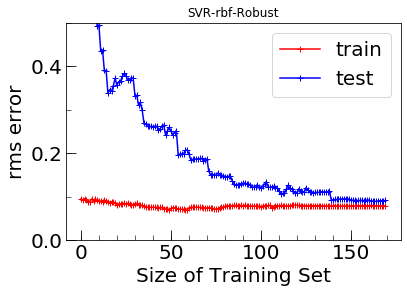

```python
mlmodel4hh_rbf5  = plot_learning_curves(rbf_Robust_regression,X,y,
                                        'SVR-rbf-Robust','hh','2',
                                        log=False)
plt.ylim(0,0.5)
plt.show()
```

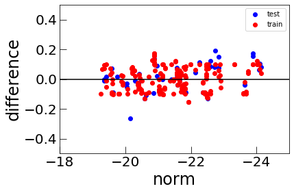

```python
results_rbf = mlmodel4hh_rbf5
yh_test = results_rbf['y_test']
yh_pred = results_rbf['y_test_pred']
df = pd.DataFrame({'Column1':yh_test,'Column2':yh_pred})
df_train = pd.DataFrame({'Column1':results_rbf['y_train'],'Column2':results_rbf['y_train_pred']})
plt.scatter(df['Column1'],df['Column2']-df['Column1'],c='b',label='test')
plt.scatter(df_train['Column1'],df_train['Column2']-df_train['Column1'],c='r',label='train')
plt.axhline(0,c='k')
plt.legend()
set_figstyle(-18,-25,-0.5,+0.5,'norm','difference')
```

*The Norm matrix elements*: taking log(n) as y during training

```python
X_features=['bet1','bet2']
X = np.array(data_dic['JJ=0'][X_features])
y = np.array(data_dic['JJ=0']['nn'])
ylog = np.log(y)
```

The following three Scalers give a similar performance.

```python
poly5_Robust_regression = Pipeline([
    ("poly_features",PolynomialFeatures(degree=5)),
    ("scaler",RobustScaler()),
    ("lin_reg",LinearRegression())
])

poly5_MM_regression = Pipeline([
    ("poly_features",PolynomialFeatures(degree=5)),
    ("scaler",MinMaxScaler()),
    ("lin_reg",LinearRegression())
])

poly5_Std_regression = Pipeline([
    ("poly_features",PolynomialFeatures(degree=5)),
    ("scaler",StandardScaler()),
    ("lin_reg",LinearRegression())
])


poly6_Std_regression = Pipeline([
    ("poly_features",PolynomialFeatures(degree=6)),
    ("scaler",StandardScaler()),
    ("lin_reg",LinearRegression())
])
```

```
for nn
```

```
(0, 0.1)
```

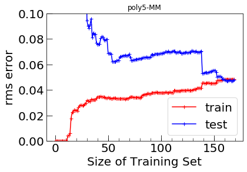

```python
mlmodel4nn_poly5  = plot_learning_curves(poly5_MM_regression,
                                         X,ylog,'poly5-MM','nn','2',
                                         log=False)
plt.ylim(0,0.1)
```

```
for nn
```

```
(0, 0.02)
```

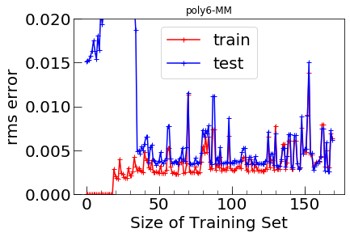

```python
mlmodel4nn_poly6  = plot_learning_curves(poly6_Std_regression,
                                         X,ylog,'poly6-MM','nn','2',
                                         log=True)
plt.ylim(0,0.02)
```

```
for nn
```

```
(0, 0.02)
```

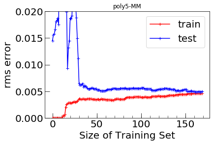

```python
mlmodel4nn_poly5  = plot_learning_curves(poly5_Std_regression,
                                         X,ylog,'poly5-MM','nn','2',
                                         log=True)
plt.ylim(0,0.02)
```

**The above figure shows the significant improvement achieved by using log(nn) in the training.**

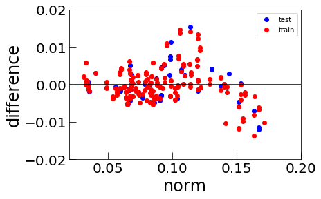

```python
results4nn = mlmodel4nn_poly5
df4nn_test  = pd.DataFrame({'Column1':results4nn['y_test'],'Column2':results4nn['y_test_pred']})
df4nn_train = pd.DataFrame({'Column1':results4nn['y_train'],'Column2':results4nn['y_train_pred']})

plt.scatter(df4nn_test['Column1'],df4nn_test['Column2']-df4nn_test['Column1'],c='b',label='test')
plt.scatter(df4nn_train['Column1'],df4nn_train['Column2']-df4nn_train['Column1'],c='r',label='train')
plt.axhline(0,c='k')
plt.legend()

set_figstyle(0.02,0.2,-0.02,+0.02,'norm','difference')
```

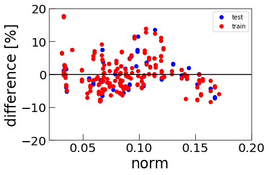

```python
results4nn = mlmodel4nn_poly5
df4nn_test  = pd.DataFrame({'Column1':results4nn['y_test'],'Column2':results4nn['y_test_pred']})
df4nn_train = pd.DataFrame({'Column1':results4nn['y_train'],'Column2':results4nn['y_train_pred']})

plt.scatter(df4nn_test['Column1'],100*(df4nn_test['Column2']-df4nn_test['Column1'])/df4nn_test['Column1'],c='b',label='test')
plt.scatter(df4nn_train['Column1'],100*(df4nn_train['Column2']-df4nn_train['Column1'])/df4nn_train['Column1'],c='r',label='train')
plt.axhline(0,c='k')
plt.legend()

set_figstyle(0.02,0.2,-20,+20,'norm','difference [%]')
```

### HWG equation

```python
m_samples =50 #-1 #200
n_mesh = 19 #18 # 30


model4hh_use =   mlmodel4hh_rbf5['models'][m_samples]
model4nn_use =   mlmodel4nn_poly5['models'][m_samples]
pData        =   Create_XData_OnMesh(n_mesh)
#pData        = Create_XData_OnMeshByRange(n_mesh,-0.4,0.4)


pfeatures    = ['bet1','bet2']
pData['hhp'] = model4hh_use.predict(pData[pfeatures])
pData['lognnp'] = model4nn_use.predict(pData[pfeatures])

pData['nnp'] = np.exp(pData['lognnp'])

# delete the data outlier
pDatar = pData[(pData['bet1']<0.4) & (pData['bet2']<0.4)]
#pDatar = pData
#pDatar.tail(10)
```

```
The eigenvalues of norm: [-2.13095120e-07 -1.24874923e-07 -2.27940377e-08  4.06258018e-07
  2.66373857e-06  3.74198885e-06  1.02132212e-05  8.15083783e-05
  1.37870928e-04  1.76111481e-03  2.37105594e-03  1.57995039e-02
  5.08046758e-02  1.24043844e-01  1.43236900e+00]
The energy of the state: [-20.652369615782895, -21.75228090237229, -21.830596982083218, -21.977477485251566, -21.996928699861535, -22.0071621870279, -22.023496362923062, -22.040467905716277, -22.04549543737467, -22.051011574582997, -22.103317360552722, -22.124030373301295]
The eigenvalues of norm: [-2.13095120e-07 -1.24874923e-07 -2.27940377e-08  4.06258018e-07
  2.66373857e-06  3.74198885e-06  1.02132212e-05  8.15083783e-05
  1.37870928e-04  1.76111481e-03  2.37105594e-03  1.57995039e-02
  5.08046758e-02  1.24043844e-01  1.43236900e+00]
The energy of the state: [-15.960670328647392, -16.95661934112475, -16.99012833244533, -16.995134846709895, -17.08246935833585, -17.1031882583619, -17.122147310649368, -17.13146813062061, -17.173481870455944, -17.266982454486552, -18.936746646130075]
The eigenvalues of norm: [-2.13095120e-07 -1.24874923e-07 -2.27940377e-08  4.06258018e-07
  2.66373857e-06  3.74198885e-06  1.02132212e-05  8.15083783e-05
  1.37870928e-04  1.76111481e-03  2.37105594e-03  1.57995039e-02
  5.08046758e-02  1.24043844e-01  1.43236900e+00]
The energy of the state: [-15.751517409612568, -16.60134770123154, -16.619621632998175, -16.95070267302671, -16.95876279816134, -16.969090361972384, -16.970487671209987, -16.984970733217146, -17.06394992032665, -17.171629809285438]
The eigenvalues of norm: [-9.40383100e-03 -5.19295987e-04 -3.29552485e-04 -2.21769589e-04
 -9.41776480e-05 -7.87229048e-05 -2.28542968e-05  5.25510294e-05
  1.65907734e-04  1.91944341e-04  6.21238227e-04  6.97459654e-03
  4.94743868e-02  1.17860809e-01  1.43023591e+00]
The energy of the state: [-20.666277217494162, -21.668019146486202, -21.726278756710805, -21.84173733740657, -21.88175306747207, -21.881940965817318, -21.895530929235562, -21.949325155071403]
The eigenvalues of norm: [-9.40383100e-03 -5.19295987e-04 -3.29552485e-04 -2.21769589e-04
 -9.41776480e-05 -7.87229048e-05 -2.28542968e-05  5.25510294e-05
  1.65907734e-04  1.91944341e-04  6.21238227e-04  6.97459654e-03
  4.94743868e-02  1.17860809e-01  1.43023591e+00]
The energy of the state: [-16.185047540912564, -16.664875765241366, -17.334273429258992, -17.393727145761506, -17.426082174041298, -17.441365169598924, -17.519692758958378]
The eigenvalues of norm: [-9.40383100e-03 -5.19295987e-04 -3.29552485e-04 -2.21769589e-04
 -9.41776480e-05 -7.87229048e-05 -2.28542968e-05  5.25510294e-05
  1.65907734e-04  1.91944341e-04  6.21238227e-04  6.97459654e-03
  4.94743868e-02  1.17860809e-01  1.43023591e+00]
The energy of the state: [-16.008906767201058, -16.65244973883094, -16.65829350805017, -16.680047060044572, -16.680163352939406, -16.68457953332698]
```

```
(0, 15)
```

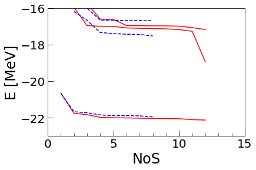

```python
# exact

dataJ0 = data[data['JJ']==0]
hhmat = df2matrix(dataJ0,'q1','q2','hh' )
nnmat = df2matrix(dataJ0,'q1','q2','nn')

nn_exact = nnmat
hh_exact = hhmat


HH0      = np.multiply(hh_exact,nn_exact)
solution = HWG_Solution(HH0,nn_exact,1,'nos',redsolid)
solution = HWG_Solution(HH0,nn_exact,2,'nos',redsolid)
solution = HWG_Solution(HH0,nn_exact,3,'nos',redsolid)


# prediction

HH       = df2matrix(pDatar,'q1','q2','hhp')
NN       = df2matrix(pDatar,'q1','q2','nnp')
HHn      = np.multiply(HH,NN)
solution = HWG_Solution(HHn,NN,1,'nos',bluedash)
solution = HWG_Solution(HHn,NN,2,'nos',bluedash)
solution = HWG_Solution(HHn,NN,3,'nos',bluedash)

set_figstyle(1,HHn.shape[0],-23,-16,'NoS','E [MeV]')

plt.xlim(0,15)
```

## Interpolation with Spline

### filter the ourliers

```python
data0 = data0[abs(data0['nn'])>0.001]
data0 = data0[(abs(data0['bet1'])<0.40) & (abs(data0['bet2'])<0.40)]
```

```python
dataJ0 = data0
coords = dataJ0['bet1'].unique()

# hamiltonian
hhmat = df2matrix(dataJ0,'q1','q2','hh')
# norm
nnmat = df2matrix(dataJ0,'q1','q2','nn')
```

### Include all the dataset in the interpolation

```python
hhi = interp.RectBivariateSpline(coords, coords, hhmat)
nni = interp.RectBivariateSpline(coords, coords, nnmat)
print("rms error for hh: {}".format(np.sqrt(mean_squared_error(hhi(*np.ix_(coords,coords)),  hhmat ))))
print("rms error for nn: {}".format(np.sqrt(mean_squared_error(nni(*np.ix_(coords,coords)),  nnmat ))))
```

```
rms error for hh: 4.431012459792239e-15
rms error for nn: 2.1736945807150597e-17
```

### Include 1/4 of the dataset in the interpolation (every second point)

```python
hhi_spare = interp.RectBivariateSpline(coords[::2], coords[::2], hhmat[::2,::2])
nni_spare = interp.RectBivariateSpline(coords[::2], coords[::2], nnmat[::2,::2])
print("rms error for hh: {}".format(np.sqrt(mean_squared_error(hhi_spare(*np.ix_(coords,coords)),  hhmat ))))
print("rms error for nn: {}".format(np.sqrt(mean_squared_error(nni_spare(*np.ix_(coords,coords)),  nnmat ))))
```

```
rms error for hh: 0.06714349353905456
rms error for nn: 0.0029656296135663705
```

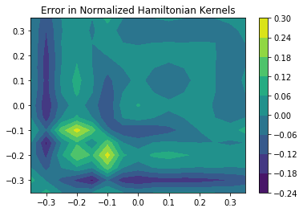

```
Text(0.5,1,'Error in Norm Kernels')
```

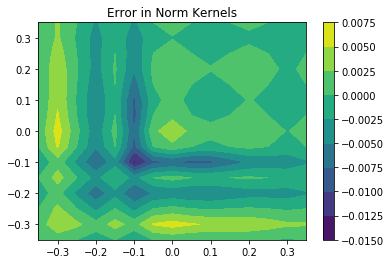

```python
plt.contourf(coords, coords, hhi_spare(*np.ix_(coords,coords)) - hhmat)
plt.xlim(-.35,.35)
plt.ylim(-.35,.35)
plt.colorbar()
plt.title("Error in Normalized Hamiltonian Kernels")
plt.show()

plt.contourf(coords, coords, nni_spare(*np.ix_(coords,coords)) - nnmat)
plt.xlim(-.35,.35)
plt.ylim(-.35,.35)
plt.colorbar()
plt.title("Error in Norm Kernels")
```

```
The eigenvalues of norm: [-2.13095120e-07 -1.24874923e-07 -2.27940377e-08  4.06258018e-07
  2.66373857e-06  3.74198885e-06  1.02132212e-05  8.15083783e-05
  1.37870928e-04  1.76111481e-03  2.37105594e-03  1.57995039e-02
  5.08046758e-02  1.24043844e-01  1.43236900e+00]
The energy of the state: [-20.652369615782895, -21.75228090237229, -21.830596982083218, -21.977477485251566, -21.996928699861535, -22.0071621870279, -22.023496362923062, -22.040467905716277, -22.04549543737467, -22.051011574582997, -22.103317360552722, -22.124030373301295]
The eigenvalues of norm: [-2.13095120e-07 -1.24874923e-07 -2.27940377e-08  4.06258018e-07
  2.66373857e-06  3.74198885e-06  1.02132212e-05  8.15083783e-05
  1.37870928e-04  1.76111481e-03  2.37105594e-03  1.57995039e-02
  5.08046758e-02  1.24043844e-01  1.43236900e+00]
The energy of the state: [-15.960670328647392, -16.95661934112475, -16.99012833244533, -16.995134846709895, -17.08246935833585, -17.1031882583619, -17.122147310649368, -17.13146813062061, -17.173481870455944, -17.266982454486552, -18.936746646130075]
The eigenvalues of norm: [-7.62436670e-17 -2.40932552e-17 -2.38837410e-17  3.03890684e-18
  1.17782171e-17  1.68214153e-17  4.62955169e-17  2.19019814e-06
  6.53702186e-05  1.91596956e-03  2.98868014e-03  1.66571899e-02
  5.03617172e-02  1.22976972e-01  1.41957407e+00]
The energy of the state: [-20.66893640012859, -21.76883550283229, -21.845439311925944, -22.000913128956732, -22.013117764272934, -22.035995515017873, -22.05993456871574, -22.07154461292473, -22.18889833981669, -26.98217270842582, -30.834310831996657, -361590101080.947]
The eigenvalues of norm: [-7.62436670e-17 -2.40932552e-17 -2.38837410e-17  3.03890684e-18
  1.17782171e-17  1.68214153e-17  4.62955169e-17  2.19019814e-06
  6.53702186e-05  1.91596956e-03  2.98868014e-03  1.66571899e-02
  5.03617172e-02  1.22976972e-01  1.41957407e+00]
The energy of the state: [-15.843297424892667, -16.712806756616114, -16.714017341568827, -16.736126615085666, -17.0619215449819, -17.125581242744243, -18.548142926893508, -19.508334096132838, -21.974914583299224, -22.00820789672313, -22.00852175637609]
```

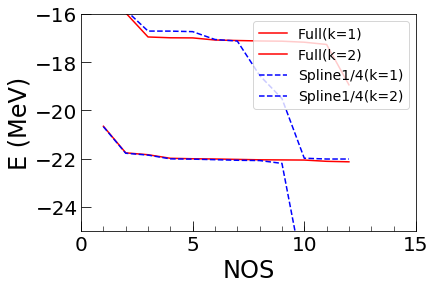

```python
# exact

nn_exact = nnmat
hh_exact = hhmat

HH0      = np.multiply(hh_exact,nn_exact)
solution = HWG_Solution(HH0,nn_exact,1,'nos',redsolid)
solution = HWG_Solution(HH0,nn_exact,2,'nos',redsolid)

# half

# nnh = nnmat[::2,::2]
# hhh = hhmat[::2,::2]

# HHh      = np.multiply(hhh,nnh)
# solution = HWG_Solution(HHh,nnh,1,'nos',blackdashdot)
# solution = HWG_Solution(HHh,nnh,2,'nos',blackdashdot)


# prediction

nn_pred  = nni_spare(*np.ix_(coords,coords))
hh_pred  = hhi_spare(*np.ix_(coords,coords))

HHp      = np.multiply(hh_pred,nn_pred)
solution = HWG_Solution(HHp,nn_pred,1,'nos',bluedash)
solution = HWG_Solution(HHp,nn_pred,2,'nos',bluedash)

plt.ylim(-25,-16)
plt.xlim(0,15)


plt.xlabel(r'NOS',fontsize=24)
plt.ylabel('E (MeV)', fontsize=24)

plt.legend(['Full(k=1)','Full(k=2)',
            'Spline1/4(k=1)','Spline1/4(k=2)'],fontsize=14)
```

### Include 1/9 of the dataset in the interpolation (every two points)

```python
hhi_spare3 = interp.RectBivariateSpline(coords[::3], coords[::3], hhmat[::3,::3])
nni_spare3 = interp.RectBivariateSpline(coords[::3], coords[::3], nnmat[::3,::3])
print("rms error for hh: {}".format(np.sqrt(mean_squared_error(hhi_spare(*np.ix_(coords,coords)),  hhmat ))))
print("rms error for nn: {}".format(np.sqrt(mean_squared_error(nni_spare(*np.ix_(coords,coords)),  nnmat ))))
```

```
rms error for hh: 0.06714349353905456
rms error for nn: 0.0029656296135663705
```

```python
hhmat[::3,::3].shape
```

```
(5, 5)
```

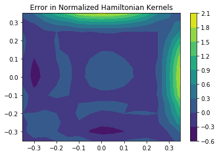

```
Text(0.5,1,'Error in Norm Kernels')
```

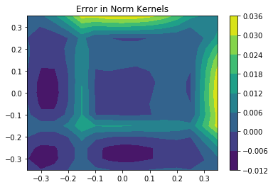

```python
plt.contourf(coords, coords, hhi_spare3(*np.ix_(coords,coords)) - hhmat)
plt.xlim(-.35,.35)
plt.ylim(-.35,.35)
plt.colorbar()
plt.title("Error in Normalized Hamiltonian Kernels")
plt.show()

plt.contourf(coords, coords, nni_spare3(*np.ix_(coords,coords)) - nnmat)
plt.xlim(-.35,.35)
plt.ylim(-.35,.35)
plt.colorbar()
plt.title("Error in Norm Kernels")
```

```
The eigenvalues of norm: [-2.13095120e-07 -1.24874923e-07 -2.27940377e-08  4.06258018e-07
  2.66373857e-06  3.74198885e-06  1.02132212e-05  8.15083783e-05
  1.37870928e-04  1.76111481e-03  2.37105594e-03  1.57995039e-02
  5.08046758e-02  1.24043844e-01  1.43236900e+00]
The energy of the state: [-20.652369615782895, -21.75228090237229, -21.830596982083218, -21.977477485251566, -21.996928699861535, -22.0071621870279, -22.023496362923062, -22.040467905716277, -22.04549543737467, -22.051011574582997, -22.103317360552722, -22.124030373301295]
The eigenvalues of norm: [-2.13095120e-07 -1.24874923e-07 -2.27940377e-08  4.06258018e-07
  2.66373857e-06  3.74198885e-06  1.02132212e-05  8.15083783e-05
  1.37870928e-04  1.76111481e-03  2.37105594e-03  1.57995039e-02
  5.08046758e-02  1.24043844e-01  1.43236900e+00]
The energy of the state: [-15.960670328647392, -16.95661934112475, -16.99012833244533, -16.995134846709895, -17.08246935833585, -17.1031882583619, -17.122147310649368, -17.13146813062061, -17.173481870455944, -17.266982454486552, -18.936746646130075]
The eigenvalues of norm: [-2.13095120e-07 -1.24874923e-07 -2.27940377e-08  4.06258018e-07
  2.66373857e-06  3.74198885e-06  1.02132212e-05  8.15083783e-05
  1.37870928e-04  1.76111481e-03  2.37105594e-03  1.57995039e-02
  5.08046758e-02  1.24043844e-01  1.43236900e+00]
The energy of the state: [-20.560086189488253, -21.581182305285697, -21.616124137032394, -21.799517024565244, -21.833518115598476, -21.866225133466813, -21.92035305487783, -21.963913813700923, -21.967858373659478, -21.97631982894286, -22.263964436694387, -44.73681984428305]
The eigenvalues of norm: [-2.13095120e-07 -1.24874923e-07 -2.27940377e-08  4.06258018e-07
  2.66373857e-06  3.74198885e-06  1.02132212e-05  8.15083783e-05
  1.37870928e-04  1.76111481e-03  2.37105594e-03  1.57995039e-02
  5.08046758e-02  1.24043844e-01  1.43236900e+00]
The energy of the state: [-16.483721602420978, -18.28907404558693, -19.586057226328233, -19.94512974322492, -21.391469364678926, -21.393383676900605, -21.430267902892076, -21.477168782299117, -21.491393806409587, -21.92576114003155, -21.989148417345174]
```

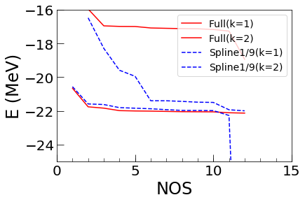

```python
# exact

nn_exact = nnmat
hh_exact = hhmat

HH0      = np.multiply(hh_exact,nn_exact)
solution = HWG_Solution(HH0,nn_exact,1,'nos',redsolid)
solution = HWG_Solution(HH0,nn_exact,2,'nos',redsolid)


# half

# nn3 = nnmat[::3,::3]
# hh3 = hhmat[::3,::3]

# HH3      = np.multiply(hh3,nn3)
# solution = HWG_Solution(HH3,nn3,1,'nos',blackdashdot)
# solution = HWG_Solution(HH3,nn3,2,'nos',blackdashdot)




# prediction

nn_pred  = nnmat #nni_spare3(*np.ix_(coords,coords))
hh_pred  = hhi_spare3(*np.ix_(coords,coords))

HHp      = np.multiply(hh_pred,nn_pred)
solution = HWG_Solution(HHp,nn_pred,1,'nos',bluedash)
solution = HWG_Solution(HHp,nn_pred,2,'nos',bluedash)

plt.ylim(-25,-16)
plt.xlim(0,15)


plt.xlabel(r'NOS',fontsize=24)
plt.ylabel('E (MeV)', fontsize=24)


plt.legend(['Full(k=1)','Full(k=2)',
            'Spline1/9(k=1)','Spline1/9(k=2)'],fontsize=14)
```

## Artificial Neural Network

For Hamiltonian kernels

```python
X = np.array(data_dic['JJ=0'][X_features])
y = np.array(data_dic['JJ=0']['hh'])
```

```python
X_train,X_test,y_train, y_test = train_test_split(X,y,test_size=0.2)
X_train.shape,y_train.shape

X4train      = X_train.T
yhh4train    = y_train.reshape(1,y_train.shape[0])

X4test      = X_test.T
yhh4test    = y_test.reshape(1,y_test.shape[0])
```

```python
# Build a model with a n_h-dimensional hidden layer

parameters4hh,error = nn_model(X4train, yhh4train, n_h = 20,
                         num_iterations = 1e6,
                         learning_rate=0.05, print_cost=True, log=False)
```

```python
# Print accuracy
predictions4hh = predict(parameters4hh, X4train)
print('rms error={}'.format(np.sqrt(mean_squared_error(yhh4train,predictions4hh))))
```

```
rms error=0.08668861946181737
```

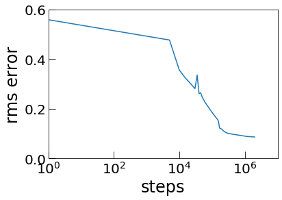

```python
plt.plot(error['steps'],error['rmse'])
plt.xscale('log')

set_figstyle(1,1e7,0,0.6,'steps','rms error')
```

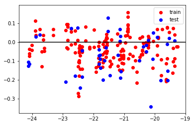

```python
# train_data
orig        = pd.DataFrame(yhh4train.T,columns=['calc.'])

predictions = predict(parameters4hh, X4train)
pred        = pd.DataFrame(predictions.T,columns=['pred.'])

#predictions4hh = predict(parameters4hh, X4train)
#pred = pd.DataFrame(predictions4hh.T,columns=['pred.'])

df4hh = pd.concat([pred,orig],axis=1)
plt.scatter(df4hh['calc.'],df4hh['pred.']-df4hh['calc.'],c='r',label='train')

# test data
orig_test = pd.DataFrame(yhh4test.T,columns=['calc.'])
pred_test = pd.DataFrame(predict(parameters4hh, X4test).T,columns=['pred.'])
df4hh_test = pd.concat([pred_test,orig_test],axis=1)
plt.scatter(df4hh_test['calc.'],df4hh_test['pred.']-df4hh_test['calc.'],
            c='b',label='test')

plt.axhline(0,c='k')
plt.legend()

#set_figstyle(0.02,0.2,-0.5,0.5,'hh','difference')
```

Norm kernels

```python
X = np.array(data_dic['JJ=0'][X_features])
y = np.log(np.array(data_dic['JJ=0']['nn']))
X.shape,y.shape
```

```
((225, 2), (225,))
```

```python
X_train,X_test,y_train, y_test = train_test_split(X,y,test_size=0.2)

X4train      = X_train.T
ynn4train    = y_train.reshape(1,y_train.shape[0])

X4test      = X_test.T
ynn4test    = y_test.reshape(1,y_test.shape[0])
```

```python
X4test.shape
```

```
(2, 45)
```

Information on the dataset:

- X4nn -- dimension(n_x=2, m=225), where n_x is the number of features, m is the number of samples
- y4nn -- dimension(n_x=1, m=225)

```python
# Build a model with a n_h-dimensional hidden layer

parameters4nn, error_nn = nn_model(X4train, ynn4train, n_h = 20,
                                   num_iterations = 1e6,
                                   learning_rate=0.1, print_cost=True, log=True)
```

```python
# Print accuracy
predictions4nn = predict(parameters4nn, X4train)
print('rms error={}'.format(np.sqrt(mean_squared_error(ynn4train,predictions4nn))))
```

```
rms error=0.03326924619773885
```

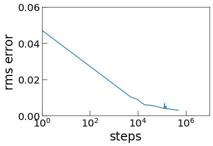

```python
plt.plot(error_nn['steps'],error_nn['rmse'])
plt.xscale('log')

set_figstyle(1,1e7,0,0.06,'steps','rms error')
```

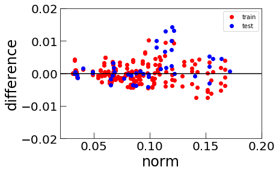

```python
# train data

orig = pd.DataFrame(np.exp(ynn4train).T,columns=['calc.']) # attention to the log

#pred = pd.DataFrame(np.exp(predictions4nn).T,columns=['pred.'])

predictions = predict(parameters4nn, X4train)
pred        = pd.DataFrame(np.exp(predictions).T,columns=['pred.'])


df4nn = pd.concat([pred,orig],axis=1)
plt.scatter(df4nn['calc.'],df4nn['pred.']-df4nn['calc.'],c='r',label='train')


# test data
orig_test = pd.DataFrame(np.exp(ynn4test).T,columns=['calc.'])

predictions = predict(parameters4nn, X4test)
pred_test   = pd.DataFrame(np.exp(predictions).T,columns=['pred.'])

df4nn_test = pd.concat([pred_test,orig_test],axis=1)
plt.scatter(df4nn_test['calc.'],df4nn_test['pred.']-df4nn_test['calc.'],
            c='b',label='test')



plt.axhline(0,c='k')
plt.legend()

set_figstyle(0.02,0.2,-0.02,+0.02,'norm','difference')
```

### HWG equation

```python
X   = np.array(data_dic['JJ=0'][X_features])
yhh = np.array(data_dic['JJ=0']['hh'])
ynn = np.array(data_dic['JJ=0']['nn'])

# log for n
ynnlog = np.log(np.array(data_dic['JJ=0']['nn']))
```

```python
X4all      = X.T
yhh4all    = yhh.reshape(1,yhh.shape[0])
ynn4all    = ynn.reshape(1,ynn.shape[0])
```

```python
ynn_pred = np.exp(predict(parameters4nn, X4all))
#yhh_pred = predict(parameters4hh, X4all)
```

```python
def Create_XData_OnFineMesh(N,step):
    q1list,q2list = Creat_Twolist4Mesh(N)
    dftest = pd.DataFrame([q1list,q2list])
    dftest = dftest.T
    dftest.columns = ['q1','q2']
    dftest['bet1'] = dftest['q1']*step-N*step/2
    dftest['bet2'] = dftest['q2']*step-N*step/2
    return dftest
```

```python
n_mesh  =   20

pData           =   Create_XData_OnFineMesh(n_mesh,0.1)

pfeatures       = ['bet1','bet2']
X4all           = pData[pfeatures].T
pData['hhp']    = predict(parameters4hh, X4all).T
pData['lognnp'] = predict(parameters4nn, X4all).T
pData['nnp']    = np.exp(pData['lognnp'])
# delete the data outlier
pDatar = pData[(pData['bet1']<0.4) & (pData['bet2']<0.4)]
#pDatar = pData
pDatar.shape
```

```
(169, 7)
```

```python
pDatar['bet1'].unique()
```

```
array([-0.9, -0.8, -0.7, -0.6, -0.5, -0.4, -0.3, -0.2, -0.1,  0. ,  0.1,
        0.2,  0.3])
```

```
The eigenvalues of norm: [-2.13095120e-07 -1.24874923e-07 -2.27940377e-08  4.06258018e-07
  2.66373857e-06  3.74198885e-06  1.02132212e-05  8.15083783e-05
  1.37870928e-04  1.76111481e-03  2.37105594e-03  1.57995039e-02
  5.08046758e-02  1.24043844e-01  1.43236900e+00]
The energy of the state: [-20.652369615782895, -21.75228090237229, -21.830596982083218, -21.977477485251566, -21.996928699861535, -22.0071621870279, -22.023496362923062, -22.040467905716277, -22.04549543737467, -22.051011574582997, -22.103317360552722, -22.124030373301295]
The eigenvalues of norm: [-2.13095120e-07 -1.24874923e-07 -2.27940377e-08  4.06258018e-07
  2.66373857e-06  3.74198885e-06  1.02132212e-05  8.15083783e-05
  1.37870928e-04  1.76111481e-03  2.37105594e-03  1.57995039e-02
  5.08046758e-02  1.24043844e-01  1.43236900e+00]
The energy of the state: [-15.960670328647392, -16.95661934112475, -16.99012833244533, -16.995134846709895, -17.08246935833585, -17.1031882583619, -17.122147310649368, -17.13146813062061, -17.173481870455944, -17.266982454486552, -18.936746646130075]
The eigenvalues of norm: [-4.69937369e-02 -6.44116708e-03 -2.26392463e-03 -1.34064901e-03
 -3.35352621e-04 -9.94548147e-05  1.29169335e-05  1.09928304e-03
  5.10491662e-03  2.09659355e-02  4.55606798e-02  7.18053819e-02
  7.20694735e-01]
The energy of the state: [-20.399037841621805, -21.090080954831148, -22.059969433236212, -22.0673642537879, -22.09304033084606, -22.139411098789214, -29.16981432990069]
The eigenvalues of norm: [-4.69937369e-02 -6.44116708e-03 -2.26392463e-03 -1.34064901e-03
 -3.35352621e-04 -9.94548147e-05  1.29169335e-05  1.09928304e-03
  5.10491662e-03  2.09659355e-02  4.55606798e-02  7.18053819e-02
  7.20694735e-01]
The energy of the state: [-15.547714521828498, -16.652295079609587, -17.422052634986006, -17.42238301803042, -17.567238452775122, -22.075358999333808]
```

```
(0, 15)
```

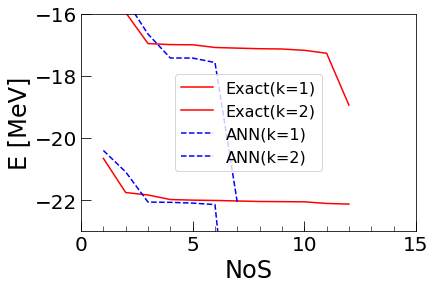

```python
# exact

dataJ0 = data[data['JJ']==0]
hhmat = df2matrix(dataJ0,'q1','q2','hh' )
nnmat = df2matrix(dataJ0,'q1','q2','nn')

nn_exact = nnmat
hh_exact = hhmat


HH0      = np.multiply(hh_exact,nn_exact)
solution = HWG_Solution(HH0,nn_exact,1,'nos',redsolid)
solution = HWG_Solution(HH0,nn_exact,2,'nos',redsolid)


# prediction

HH       = df2matrix(pDatar,'q1','q2','hhp')
NN       = df2matrix(pDatar,'q1','q2','nnp')
HHn      = np.multiply(HH,NN)
solution = HWG_Solution(HHn,NN,1,'nos',bluedash)
solution = HWG_Solution(HHn,NN,2,'nos',bluedash)

set_figstyle(1,HHn.shape[0],-23,-16,'NoS','E [MeV]')

plt.legend(['Exact(k=1)','Exact(k=2)','ANN(k=1)','ANN(k=2)'],fontsize=16)
plt.xlim(0,15)
```

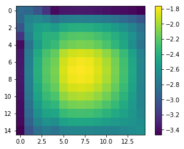

```python
plt.imshow(np.log(nnmat))
plt.colorbar()
```

# Conclusion

$$ N^{J=0}(q_1, q_2) = <\Phi(q_1)\vert \hat P^J \hat P^N \vert\Phi(q_2)\rangle, $$

and

$$ H^{J=0}(q_1, q_2) = <\Phi(q_1)\vert \hat H\hat P^J \hat P^N \vert\Phi(q_2)\rangle, $$ where $\hat H$ is the hamiltonian operator. The findings are summarized as below:

The next step will be considering higher dimension case.